# Final Project: Predicting Manhattan Home Sales

Data Cleaning and Wrangling

# Data Cleaning

```r
manhattan <- read.csv("https://raw.githubusercontent.com/lcao21/GIS3_Final_Project/master/Data/manhattan.csv", stringsAsFactors=FALSE)
head(manhattan)
```

```
##   BOROUGH  NEIGHBORHOOD        BUILDING.CLASS.CATEGORY TAX.CLASS.AT.PRESENT
## 1       1 ALPHABET CITY        01 ONE FAMILY DWELLINGS                    1
## 2       1 ALPHABET CITY        01 ONE FAMILY DWELLINGS                    1
## 3       1 ALPHABET CITY        02 TWO FAMILY DWELLINGS                    1
## 4       1 ALPHABET CITY      03 THREE FAMILY DWELLINGS                    1
## 5       1 ALPHABET CITY      03 THREE FAMILY DWELLINGS                    1
## 6       1 ALPHABET CITY 07 RENTALS - WALKUP APARTMENTS                    2
##   BLOCK LOT EASE.MENT BUILDING.CLASS.AT.PRESENT              ADDRESS
## 1   376  43        NA                        S1  743 EAST 6TH STREET
## 2   390  61        NA                        A4  189 EAST 7TH STREET
## 3   404   1        NA                        B9         166 AVENUE A
## 4   377  56        NA                        C0  263 EAST 7TH STREET
## 5   393   9        NA                        C0 604 EAST 11TH STREET
## 6   372  23        NA                        C1  300 EAST 3RD STREET
##   APARTMENT.NUMBER ZIP.CODE RESIDENTIAL.UNITS COMMERCIAL.UNITS TOTAL.UNITS
```

[output cut: 20 more lines]

## Remove unimportant columns

```r
drops <- c("BOROUGH","EASE.MENT", "TAX.CLASS.AT.PRESENT", "BUILDING.CLASS.AT.PRESENT", "APARTMENT.NUMBER")
manhattan <- manhattan[ , !(names(manhattan) %in% drops)]
head(manhattan)
```

```
##    NEIGHBORHOOD        BUILDING.CLASS.CATEGORY BLOCK LOT              ADDRESS
## 1 ALPHABET CITY        01 ONE FAMILY DWELLINGS   376  43  743 EAST 6TH STREET
## 2 ALPHABET CITY        01 ONE FAMILY DWELLINGS   390  61  189 EAST 7TH STREET
## 3 ALPHABET CITY        02 TWO FAMILY DWELLINGS   404   1         166 AVENUE A
## 4 ALPHABET CITY      03 THREE FAMILY DWELLINGS   377  56  263 EAST 7TH STREET
## 5 ALPHABET CITY      03 THREE FAMILY DWELLINGS   393   9 604 EAST 11TH STREET
## 6 ALPHABET CITY 07 RENTALS - WALKUP APARTMENTS   372  23  300 EAST 3RD STREET
##   ZIP.CODE RESIDENTIAL.UNITS COMMERCIAL.UNITS TOTAL.UNITS LAND.SQUARE.FEET
## 1    10009                 1                1           2            2,090
## 2    10009                 1                0           1              987
## 3    10009                 2                0           2            1,510
## 4    10009                 3                0           3            2,430
## 5    10009                 3                0           3            2,375
## 6    10009                12                0          12            2,393
##   GROSS.SQUARE.FEET YEAR.BUILT TAX.CLASS.AT.TIME.OF.SALE
## 1             3,680       1940                         1
## 2             2,183       1860                         1
## 3             4,520       1900                         1
## 4             3,600       1899                         1
## 5             5,110       1939                         1
## 6             7,989       2001                         2
##   BUILDING.CLASS.AT.TIME.OF.SALE SALE.PRICE SALE.DATE
## 1                             S1  3,200,000   7/24/19
## 2                             A4          0   9/25/19
## 3                             B9          0   7/22/19
## 4                             C0  6,300,000   4/30/19
## 5                             C0          0  10/24/19
## 6                             C1  1,950,000    8/8/19
```

## Keep only rows for family dwellings

```r
library(data.table)
manhattan <- manhattan[manhattan$BUILDING.CLASS.CATEGORY %like% "FAMILY", ]
```

## Keep only rows that have non-zero values for sale price

```r
manhattan <-manhattan[!(manhattan$"SALE.PRICE"== 0),]

replace_commas<-function(x){
  x<-as.numeric(gsub("\\,", "", x))
}

manhattan$SALE.PRICE <- replace_commas(manhattan$SALE.PRICE)
manhattan$SALE.PRICE <- as.numeric(manhattan$SALE.PRICE)
```

# Geocoding

## Clean addresses

```r
library(stringr)
# Convert addresses to type character
manhattan$ADDRESS <- as.character(manhattan$ADDRESS)

# Remove anything before a dash, before a slash, and after a comma
manhattan$ADDRESS <- gsub(".*-","", manhattan$ADDRESS)
manhattan$ADDRESS <- gsub(".*/","", manhattan$ADDRESS)
manhattan$ADDRESS <- gsub("(.*),.*", "\\1", manhattan$ADDRESS)

# Remove rows with address lengths less than 3
manhattan$address_length <- c(str_count(manhattan$ADDRESS))
manhattan <- manhattan[!(manhattan$address_length < 3),]

# Add ", Manhattan" to each address
manhattan$ADDRESS <- paste(manhattan$ADDRESS, ", Manhattan", sep="")
```

```r
library(ggmap)
library(OpenStreetMap)
library(tmaptools)

geocoded_addresses <- geocode_OSM(manhattan$ADDRESS, as.data.frame = TRUE)
geocoded_addresses <- geocoded_addresses[c("query","lat", "lon")]
head(geocoded_addresses)
write.csv(geocoded_addresses,"geocoded_addresses.csv", row.names = FALSE)
```

Since running the above chunk took a very long time, I exported the dataframe output as a csv called “geocoded_addresses.csv”, so that I can use the csv whenever I need to re-run the markdown file without having to wait >= 5 minutes.

```r
geocoded_addresses <- read.csv("https://raw.githubusercontent.com/lcao21/GIS3_Final_Project/master/Data/geocoded_addresses.csv")
head(geocoded_addresses)
```

```
##                             query      lat       lon
## 1  743 EAST 6TH STREET, Manhattan 40.72290 -73.97740
## 2  189 EAST 7TH STREET, Manhattan 40.72493 -73.98051
## 3         166 AVENUE A, Manhattan 40.72811 -73.98174
## 4  263 EAST 7TH STREET, Manhattan 40.72363 -73.97741
## 5 604 EAST 11TH STREET, Manhattan 40.72712 -73.97916
## 6 483 WEST 22ND STREET, Manhattan 40.74700 -74.00411
```

The geocode_OSM() function couldn’t find a few addresses that aren’t huge losses so I’ll ignore those lost rows and merge the geocoded_addresses df with my manhattan df. In the case, since manhattan has more rows than geocoded_addresses, I conduct an “inner join” with merge():

```r
library(dplyr)

# Inner join
manhattan <- merge(manhattan, geocoded_addresses, by.x = "ADDRESS", by.y = "query")
```

```r
# Drop address_length column
manhattan <- manhattan[ , !(names(manhattan) %in% c("address_length"))]
head(manhattan)
```

```
##                           ADDRESS              NEIGHBORHOOD
## 1       1 SUTTON PLACE, Manhattan              MIDTOWN EAST
## 2 106 EAST 78TH STREET, Manhattan   UPPER EAST SIDE (59-79)
## 3 109 WEST 11TH STREET, Manhattan    GREENWICH VILLAGE-WEST
## 4   11 EAST 129 STREET, Manhattan            HARLEM-CENTRAL
## 5  11 WEST 12TH STREET, Manhattan GREENWICH VILLAGE-CENTRAL
## 6 110 WASHINGTON PLACE, Manhattan    GREENWICH VILLAGE-WEST
##     BUILDING.CLASS.CATEGORY BLOCK LOT ZIP.CODE RESIDENTIAL.UNITS
## 1   01 ONE FAMILY DWELLINGS  1372  26    10022                 1
## 2   01 ONE FAMILY DWELLINGS  1412  68    10075                 1
## 3   01 ONE FAMILY DWELLINGS   607  50    10011                 1
## 4   01 ONE FAMILY DWELLINGS  1754   8    10035                 1
## 5   01 ONE FAMILY DWELLINGS   576  48    10011                 1
## 6 03 THREE FAMILY DWELLINGS   592  14    10014                 3
##   COMMERCIAL.UNITS TOTAL.UNITS LAND.SQUARE.FEET GROSS.SQUARE.FEET YEAR.BUILT
```

[output cut: 20 more lines]

An entry has really suspicious lat and lon columns, as they’re both wildly different than the others:

```
##            manhattan[6, ]$ADDRESS manhattan[6, ]$lat manhattan[6, ]$lon
## 1 110 WASHINGTON PLACE, Manhattan           14.27621           120.9661
```

Using https://www.latlong.net/convert-address-to-lat-long.html, I found the right lat and lon and manually replaced the column values.

```r
manhattan[6,]$lat <- 40.732422
manhattan[6,]$lon <- -74.001152

# Check the min and max of lat and lon that will also be used for mapping
height <- max(manhattan$lat) - min(manhattan$lat)
width <- max(manhattan$lon) - min(manhattan$lon)
borders <- c(bottom  = min(manhattan$lat)  - 0.2 * height,
             top     = max(manhattan$lat)  + 0.2 * height,
             left    = min(manhattan$lon) - 0.2 * width,
             right   = max(manhattan$lon) + 0.2 * width)
borders
```

```
##    bottom       top      left     right
##  40.67401  40.91134 -74.03133 -73.88918
```

# Mapping Manhattan homes

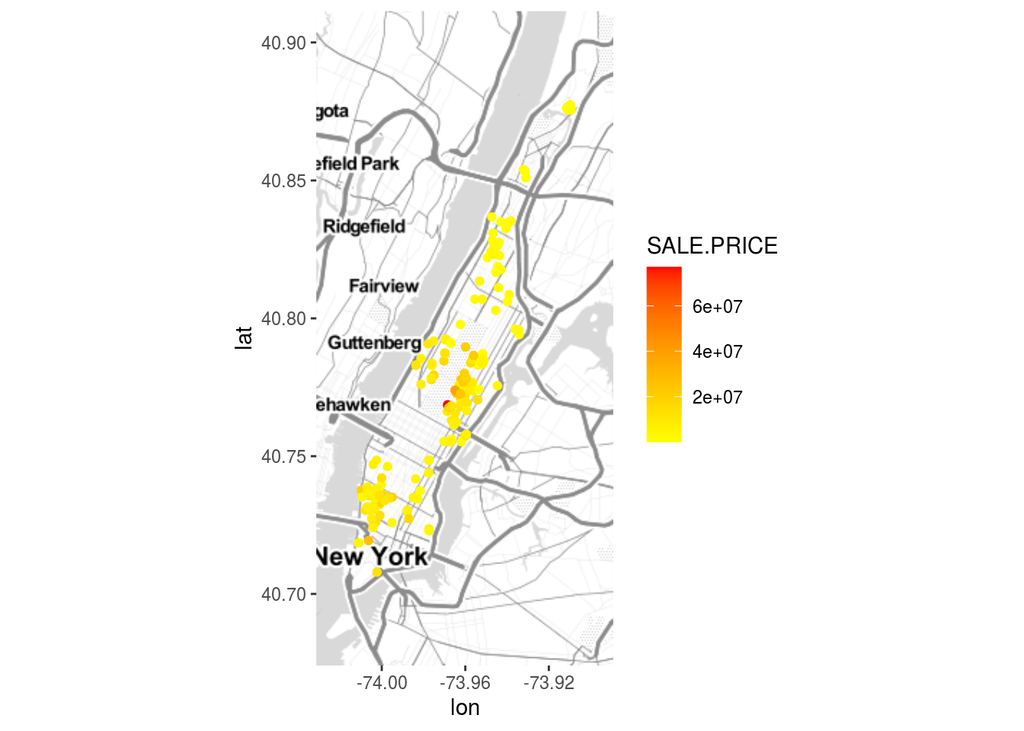

```r
library(lubridate)
library(ggplot2)
library(ggrepel)
library(tidyverse)
library(ggmap)
library(osmdata)

map <- get_stamenmap(borders, zoom = 11, maptype = "toner-lite")
ggmap(map) +
  geom_point(data = manhattan, mapping = aes(x = lon, y = lat,
  col = SALE.PRICE)) +
  scale_color_gradient(low = "yellow", high = "red")
```

I’ll be doing more data exploration once I merge the current manhattan df with the 6 other datasets. I just wanted to output one simple map before doing so. It seems that the most expensive homes are located around Central Park (Upper East Side, Upper West Side), Greenwich Village, and SoHo.

# Merging 6 variable datasets

# Schools

```r
schools <- read.csv("https://raw.githubusercontent.com/lcao21/GIS3_Final_Project/master/Data/schools.csv", stringsAsFactors = FALSE)
schools$LATITUDE <- as.numeric(schools$LATITUDE)
schools$LONGITUDE <- as.numeric(schools$LONGITUDE)
```

## Remove rows with zeros for longitude and latitude

```r
schools <-schools[!(schools$"LONGITUDE"== 0),]
schools <- schools[with(schools, order(LONGITUDE)),]
```

## Filter for Manhattan schools

```r
m_districts <- c(1,2,3,4,5,6,7,8,9,10)
schools <- schools[schools$Council.district %in% m_districts, ]
```

I found that filtering for council districts was the most accurate way of finding schools located in Manhattan. I initally tried using community district but the community district scale here is much different than the ones I found on the NYC.gov website. According to https://council.nyc.gov/districts/, Manhattan council districts are from 1 to 10 inclusive, though district 8 represents parts of Manhattan and the Bronx.

Next, I want to determine how far each school is from a home property, but for each property, I only care about schools within a certain proximity. Furthermore, since high schools aren’t subject to school zoning laws, distance betwen home and school is weighed more than for middle and elementary schools, which are assigned based on where students’ live. Although school zoning rules probably affect proprty sales (i.e. there’s a premium on property sales near the best public high school in Manhattan), I assume that more weight is put on attending good *high schools* rather than *middle or elementary schools*, since the former imapcts college acceptances and thus its quality is more important to parents and students.

## Filter out schools that don’t serve grades 9-12

```r
hs_grades <- c("09,10,11,12")
schools <- schools[schools$Grades_text %like% hs_grades, ]
```

## Quick map of final schools

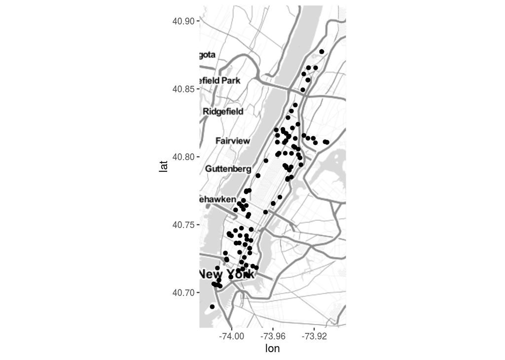

```r
ggmap(map) +
  geom_point(data = schools, mapping = aes(x = LONGITUDE, y = LATITUDE))
```

```r
library(sf)
library(rgeos)
library(rgdal)

manhattan_copy <- copy(manhattan)
coordinates(manhattan_copy) <- c("lon", "lat")
proj4string(manhattan_copy) <- CRS("+init=epsg:4326")
manhattan_sf <- st_as_sf(manhattan_copy) %>% st_transform(2263) # nad83
manhattan_sf_buff <- st_buffer(manhattan_sf, 1609.34)
manhattan_sf_buff$home_ID <- seq.int(nrow(manhattan_sf_buff))

manhattan_sf_buff <- subset(manhattan_sf_buff, select=c("home_ID", "geometry"))

head(as.data.frame(manhattan_sf_buff))
```

```
##   home_ID                       geometry
## 1       1 POLYGON ((996855.6 215213.3...
## 2       2 POLYGON ((996782.7 221474.6...
## 3       3 POLYGON ((986228.4 207337.2...
## 4       4 POLYGON ((996430 214430.1, ...
## 5       5 POLYGON ((987229.7 207089.4...
## 6       6 POLYGON ((985540.1 206117.7...
```

I go through a similar process of transforming the schools dataframe of coverting it into an sf object, re-projecting it to the EPSG:2263 projected coordinate system, and creating a column of unique, integer IDs. Ultimately, I get an sf object called **schools_sf** that has two fields: school_ID and *geometry*; geometry is of point geometry and represents each school.

```r
schools_copy <- copy(schools)
coordinates(schools_copy) <- c("LONGITUDE", "LATITUDE")
proj4string(schools_copy) <- CRS("+init=epsg:4326")
schools_sf <- st_as_sf(schools_copy) %>% st_transform(2263)
schools_sf$school_ID <- seq.int(nrow(schools_sf))
schools_sf <- subset(schools_sf, select=c("school_ID", "geometry"))

head(as.data.frame(schools_sf))
```

```
##      school_ID                  geometry
## 1079         1 POINT (978997.2 190477.9)
## 1080         2 POINT (978997.2 190477.9)
## 757          3 POINT (979410.2 196631.7)
## 1113         4 POINT (979859.1 196347.8)
## 1029         5   POINT (980391 200872.7)
## 911          6 POINT (980561.6 196377.9)
```

## Plot of all homes and schools

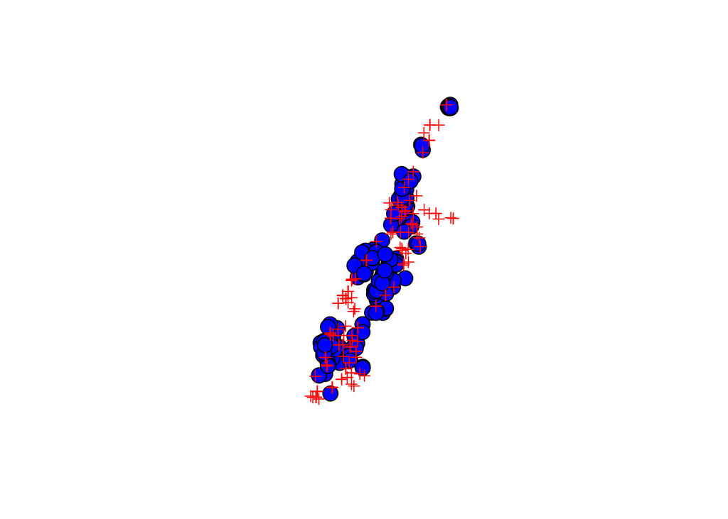

```r
plot(manhattan_sf_buff$geometry, col="Blue")
plot(st_geometry(schools_sf), pch = 3, col = "Red", add= TRUE)
```

To calculate the intersections between the homes and high schools, I use the *st_intersection()* function from the sf library.

## Calculate intersection

```r
intersection <- st_intersection(x = manhattan_sf_buff, y = schools_sf)
```

## Plot of all homes and only schools that intersect

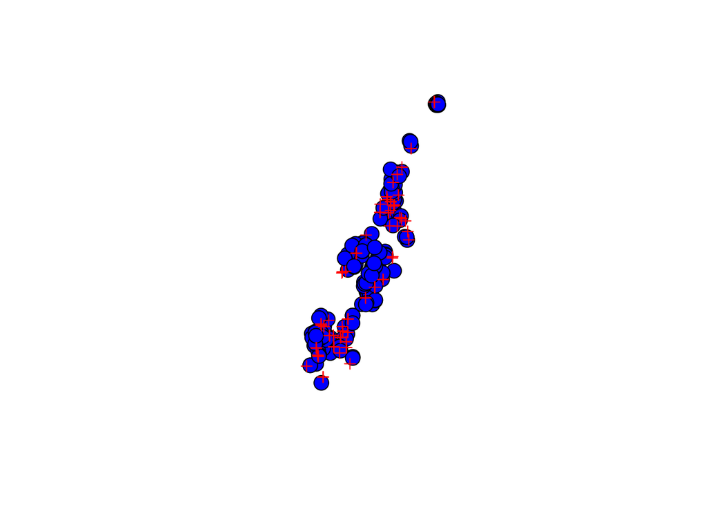

```r
plot(manhattan_sf_buff$geometry, col="Blue")
plot(intersection, col = "Red", pch = 3, add = TRUE)
```

## Calculate the number of schools within the buffer of each home

```r
int_result <- intersection %>%
  group_by(home_ID) %>%
  count()

head(int_result)
```

```
## Simple feature collection with 6 features and 2 fields
## geometry type:  GEOMETRY
## dimension:      XY
## bbox:           xmin: 982544.1 ymin: 203016.9 xmax: 999668.1 ymax: 236294.8
## CRS:            EPSG:2263
## # A tibble: 6 x 3
## # Groups:   home_ID [6]
##   home_ID     n                                                         geometry
##     <int> <int>                                      <GEOMETRY [US_survey_foot]>
## 1       3     2                                        POINT (985433.1 207572.8)
## 2       5     3              MULTIPOINT ((985433.1 207572.8), (986265.6 207613))
## 3       8     1                                        POINT (993448.1 229696.9)
## 4      10     5 MULTIPOINT ((982544.1 204889.9), (982848 203278.8), (982949.5 2…
## 5      11     4 MULTIPOINT ((998395 234567.8), (998833.5 235072), (999474.2 236…
## 6      12     4                                        POINT (991316.2 225687.7)
```

Now we have to left join the manhattan dataframe with int_result. First, I created the same column of unique, integer ID for manhattan so that I can join the two dataframes with the shared home_ID column. After the merge, homes that don’t have schools within its buffer have NA values in the “n” column so I replace those with zeros and rename the column *num_schools*. I call this final dataframe **manhattan_int_schools**.

## Left join manhattan with int_result

```r
manhattan$home_ID <- seq.int(nrow(manhattan))
manhattan_int_schools <- merge(x = manhattan, y = int_result, by = "home_ID", all.x = TRUE)
manhattan_int_schools$n[is.na(manhattan_int_schools$n)] <- 0
colnames(manhattan_int_schools)[20] <- "num_schools"

head(manhattan_int_schools)
```

```
##   home_ID                         ADDRESS              NEIGHBORHOOD
## 1       1       1 SUTTON PLACE, Manhattan              MIDTOWN EAST
## 2       2 106 EAST 78TH STREET, Manhattan   UPPER EAST SIDE (59-79)
## 3       3 109 WEST 11TH STREET, Manhattan    GREENWICH VILLAGE-WEST
## 4       4   11 EAST 129 STREET, Manhattan            HARLEM-CENTRAL
## 5       5  11 WEST 12TH STREET, Manhattan GREENWICH VILLAGE-CENTRAL
## 6       6 110 WASHINGTON PLACE, Manhattan    GREENWICH VILLAGE-WEST
##     BUILDING.CLASS.CATEGORY BLOCK LOT ZIP.CODE RESIDENTIAL.UNITS
## 1   01 ONE FAMILY DWELLINGS  1372  26    10022                 1
## 2   01 ONE FAMILY DWELLINGS  1412  68    10075                 1
## 3   01 ONE FAMILY DWELLINGS   607  50    10011                 1
## 4   01 ONE FAMILY DWELLINGS  1754   8    10035                 1
## 5   01 ONE FAMILY DWELLINGS   576  48    10011                 1
## 6 03 THREE FAMILY DWELLINGS   592  14    10014                 3
##   COMMERCIAL.UNITS TOTAL.UNITS LAND.SQUARE.FEET GROSS.SQUARE.FEET YEAR.BUILT
```

[output cut: 20 more lines]

## Map of only homes and schools that intersect

```r
# Schools that intersect with homes
test <- st_transform(intersection, crs = 4326)
schools_that_int <- as.data.frame(test)
schools_that_int <- schools_that_int[!duplicated(schools_that_int[,c("school_ID")]),]

schools$school_ID <- seq.int(nrow(schools))

test2 <- merge(schools, schools_that_int)
head(test2)
```

```
##   school_ID fiscal_year system_code location_code
## 1         5        2020      02M475          M475
## 2        13        2020      75M721          M721
## 3        14        2020      75M721          M721
## 4        15        2020      02M376          M376
## 5        16        2020      02M615          M615
## 6        17        2020      84M522          M522
##                                        location_name         BEDS
## 1                             Stuyvesant High School 310200011475
## 2 P.S. M721 - Manhattan Occupational Training Center 307500011721
## 3 P.S. M721 - Manhattan Occupational Training Center 307500011721
## 4                                        NYC iSchool 310200011376
## 5 Chelsea Career and Technical Education High School 310200011615
## 6               Broome Street Academy Charter School 310200860992
##   Managed_by_name location_type_description Location_Category_Description
```

[output cut: 90 more lines]

```r
# Homes with at least 1 school in its buffer
test3 <- manhattan_int_schools[manhattan_int_schools$num_schools > 0,]
head(test3)
```

```
##    home_ID                          ADDRESS              NEIGHBORHOOD
## 3        3  109 WEST 11TH STREET, Manhattan    GREENWICH VILLAGE-WEST
## 5        5   11 WEST 12TH STREET, Manhattan GREENWICH VILLAGE-CENTRAL
## 8        8  115 MANHATTAN AVENUE, Manhattan          MANHATTAN VALLEY
## 10      10   116 SULLIVAN STREET, Manhattan                      SOHO
## 11      11 116 WEST 130TH STREET, Manhattan            HARLEM-CENTRAL
## 12      12  116 WEST 80TH STREET, Manhattan   UPPER WEST SIDE (79-96)
##      BUILDING.CLASS.CATEGORY BLOCK LOT ZIP.CODE RESIDENTIAL.UNITS
## 3    01 ONE FAMILY DWELLINGS   607  50    10011                 1
## 5    01 ONE FAMILY DWELLINGS   576  48    10011                 1
## 8    02 TWO FAMILY DWELLINGS  1840 152    10025                 2
## 10   02 TWO FAMILY DWELLINGS   504  29    10012                 2
## 11 03 THREE FAMILY DWELLINGS  1914  41    10027                 3
## 12   01 ONE FAMILY DWELLINGS  1210 142    10024                 1
##    COMMERCIAL.UNITS TOTAL.UNITS LAND.SQUARE.FEET GROSS.SQUARE.FEET YEAR.BUILT
```

[output cut: 20 more lines]

[figure not shown]

```r
map2 <- get_stamenmap(borders, zoom = 11, maptype = "terrain")

ggmap(map2) +
  geom_point(data = test2, mapping = aes(x = LONGITUDE, y = LATITUDE), col="Blue") +
  geom_point(data = test3, mapping = aes(x = lon, y = lat), col="Red", shape=3)
```